# Generalized additve modeling of precipitation extremes

2024-02-15

We first load R packages required for running the following code.

```r
pkgTest <- function(x)
  {
    if (!require(x,character.only = TRUE))
    {
      install.packages(x,dep=TRUE)
        if(!require(x,character.only = TRUE)) stop("Package not found")
    }
}
pkgTest("evgam")
```

```r
pkgTest("ggplot2")
pkgTest("ggspatial")
pkgTest("rnaturalearth")
pkgTest("viridis")
pkgTest("xts")
```

We start by loading and inspecting the data file including the following two R objects: * alldata, a dataframe with daily precipitation data for raingauges in Germany. * metadata, a dataframe with metadata for raingauges, including their spatial coordinates.

```r
load("daily_rainfall_germany.Rdata")
dim(alldata)
```

```
## [1] 71680   191
```

```r
mean(is.na(alldata))
```

```
## [1] 0.3940691
```

```r
names(alldata) = paste0("y", 1:191)
```

We select data for the period starting with year 1901 and extract topographic coordinates (latitude; longitude; altitude in meters) of raingauges.

```r
idx = index(alldata)
years = as.numeric(format(idx, "%Y"))
unique(years)
```

```
##   [1] 1827 1828 1829 1830 1831 1832 1833 1834 1835 1836 1837 1838 1839 1840 1841
##  [16] 1842 1843 1844 1845 1846 1847 1848 1849 1850 1851 1852 1853 1854 1855 1856
##  [31] 1857 1858 1859 1860 1861 1862 1863 1864 1865 1866 1867 1868 1869 1870 1871
##  [46] 1872 1873 1874 1875 1876 1877 1878 1879 1880 1881 1882 1883 1884 1885 1886
##  [61] 1887 1888 1889 1890 1891 1892 1893 1894 1895 1896 1897 1898 1899 1900 1901
##  [76] 1902 1903 1904 1905 1906 1907 1908 1909 1910 1911 1912 1913 1914 1915 1916
##  [91] 1917 1918 1919 1920 1921 1922 1923 1924 1925 1926 1927 1928 1929 1930 1931
## [106] 1932 1933 1934 1935 1936 1937 1938 1939 1940 1941 1942 1943 1944 1945 1946
## [121] 1947 1948 1949 1950 1951 1952 1953 1954 1955 1956 1957 1958 1959 1960 1961
## [136] 1962 1963 1964 1965 1966 1967 1968 1969 1970 1971 1972 1973 1974 1975 1976
## [151] 1977 1978 1979 1980 1981 1982 1983 1984 1985 1986 1987 1988 1989 1990 1991
## [166] 1992 1993 1994 1995 1996 1997 1998 1999 2000 2001 2002 2003 2004 2005 2006
## [181] 2007 2008 2009 2010 2011 2012 2013 2014 2015 2016 2017 2018 2019 2020 2021
## [196] 2022 2023
```

```r
id_sel = which(years > 1900)
alldata = alldata[years > 1900,]
years = years[id_sel]
lat = metadata$geoBreite
lon = metadata$geoLaenge
alt = metadata$Stationshoehe
```

Next, we compute empirical locationwise quantiles at level 0.98. If there are more than 25% of missing data at a location, we set its quantile to NA.

```r
# get high quantiles
myfun = function(vec, prob = 0.98){
  if(mean(is.na(vec)) > 0.25){
    NA
  }else{
    quantile(vec, 0.98, na.rm = TRUE)
  }
}
u = as.vector(sapply(alldata, myfun))
mean(is.na(u))
```

```
## [1] 0.104712
```

```r
u
```

```
##   [1] 28.000 14.500 12.400 12.700 15.000 13.200 12.100 12.600 13.200 11.800
##  [11] 13.530 14.700 14.200 30.100 16.600 14.800 13.600 12.000 16.500 17.200
##  [21] 23.700 15.400 16.100 14.200 12.600 21.500 25.300 14.100 27.700 12.400
##  [31] 13.300 11.912 16.900 16.900 13.100 14.600     NA 14.560 13.300 16.500
##  [41] 15.800 13.900 24.100 17.500 25.000 14.600 16.600 13.100 21.400 13.000
##  [51]     NA 19.400 34.900 13.000 12.500 14.000     NA     NA 14.700 15.700
##  [61] 12.800 13.800 13.800 18.500     NA 13.500 13.700 13.500 15.800 17.000
##  [71] 13.800 13.900 14.700 15.900 13.000 24.200 20.000 15.300 35.700 13.500
##  [81] 18.200 14.700 14.200 12.700 22.400 15.100 25.100 14.400 12.600 14.900
##  [91] 16.100     NA 16.200 17.800 16.600 17.900 12.300 16.000 15.000 13.600
## [101] 12.584 15.550 12.800 14.400     NA 16.400 11.900     NA 14.700 14.400
## [111] 15.900 14.000 14.600 17.870 20.100 13.600 12.800 20.588 12.500 13.200
## [121] 12.200     NA 26.400 14.200 13.800 13.400 15.000 14.000 15.000 33.600
## [131]     NA 17.400 17.000     NA     NA 15.100 18.500 14.400 20.412 13.100
## [141] 17.300     NA 13.600 15.900 12.400 19.800     NA 14.600     NA 14.100
## [151] 12.600     NA 14.874 15.000 12.000 14.900     NA     NA 13.400 26.800
## [161] 13.800     NA 12.700 16.100 36.842 13.800 15.800 12.400 15.200 12.900
## [171] 26.016 15.300 13.000 17.900 24.100 16.400 13.738     NA 12.800 12.800
## [181] 13.600 15.200 13.900 13.200 32.000 15.724 13.500 31.900 18.500 15.700
## [191] 16.100
```

We can now generate a nice map (using ggplot and rnaturalearth) of the available raingauges. We here opt for the viridis color scale.

```
## Scale on map varies by more than 10%, scale bar may be inaccurate
```

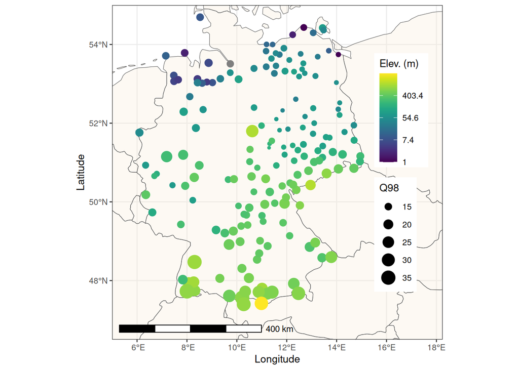

```r
world = ne_countries(scale = "medium", returnclass = "sf")
df_gg = data.frame(lon = lon, lat = lat, alt = alt, Q98 = u)
pl = ggplot(data = world) + theme_bw(base_size = 10)
pl = pl + geom_sf(fill= "antiquewhite", alpha = .3)
#pl = pl + geom_text(data= country.names,aes(x=X, y=Y, label=name), color = 'darkblue', fontface = 'bold', size = 8)
pl = pl + annotation_scale(location = 'bl', width_hint = 0.5)
#pl = pl + annotation_north_arrow(location = 'bl', which_north = 'true', pad_x = unit(0.5, 'in'), pad_y = unit(0.5, 'in'), style = north_arrow_fancy_orienteering)
pl = pl + coord_sf(xlim = c(5, 18.25), ylim = c(46.5,55), expand = FALSE)
pl = pl + xlab('Longitude') + ylab('Latitude')
pl = pl + geom_point(aes(x = lon, y = lat, colour = alt, size = Q98), data = df_gg)
pl = pl + scale_color_gradientn(colours = viridis(16), trans = "log", labels = function(x) round(x,1))
pl = pl + labs(colour = "Elev. (m)")
pl = pl + theme(legend.position = c(0.875, 0.5))
print(pl)
```

We cut away the Alpine region in the South (below 48 degrees latitude) since it could have a sensibly different hydroclimate.

```r
lat_bnd = 48

ids_keep = which(lat >= lat_bnd)
lat = lat[ids_keep]
lon = lon[ids_keep]
alt = alt[ids_keep]
metadata = metadata[ids_keep,]
alldata = alldata[, ids_keep]
```

Next, we extract a matrix with annual maxima for each location. The extraction function returns NA if there is no complete record for the year and also if there are more than 10 missing observations in a year. We then generate a dataframe for fitting a generalized additive GEV model (see book chapter for the regression equations) with the evgam package.

```r
mymax = function(vec){
  if(length(vec) < 365 | sum(is.na(vec)) > 10){
    return(NA)
  }else{
    return(max(vec, na.rm = TRUE))
  }
}
maxima = aggregate(alldata ~ years, FUN = mymax, na.action = na.pass)
max_mat = as.matrix(maxima[,-1])
dim(max_mat)
```

```
## [1] 123 176
```

```r
y_max = as.numeric(max_mat)
df = data.frame(y = y_max, lat = rep(lat, each = nrow(max_mat)), lon = rep(lon, each = nrow(max_mat)))
df$year =  rep(maxima$years, ncol(max_mat))
```

We fit a GAM with a GEV response including a bivariate thin-plate splines with 50 knots for the spatial coordinates in the parameters mu and sigma, a cubic regression spline for a nonlinear effect of year in mu and sigma, and a shape parameter that does not depend on covariates.

```r
fit = evgam(list(y ~ s(lon, lat, k = 50) + s(year,  bs = "cr"), ~ s(lon, lat, k = 50)  + s(year,  bs = "cr"), ~ 1),
            data = df, family ="gev")
summary(fit)
```

```
##
## ** Parametric terms **
##
## location
##             Estimate Std. Error t value Pr(>|t|)
## (Intercept)    29.78       0.08  384.04   <2e-16
##
## logscale
##             Estimate Std. Error t value Pr(>|t|)
## (Intercept)     2.23       0.01  356.52   <2e-16
##
## shape
##             Estimate Std. Error t value Pr(>|t|)
## (Intercept)     0.13       0.01   22.64   <2e-16
##
## ** Smooth terms **
##
## location
##              edf max.df  Chi.sq Pr(>|t|)
## s(lon,lat) 45.36     49 1649.53   <2e-16
## s(year)     7.84      9  131.12   <2e-16
##
## logscale
##              edf max.df Chi.sq Pr(>|t|)
## s(lon,lat) 38.36     49 399.11   <2e-16
## s(year)     3.81      9   9.30    0.071
```

We could also consider a model having a simpler linear effect of the year covariate.

```r
fit2 = evgam(list(y ~ s(lon, lat, k = 50) + year, ~ s(lon, lat, k = 50)  + year, ~ 1),
            data = df, family ="gev")
summary(fit2)
```

```
##
## ** Parametric terms **
##
## location
##             Estimate Std. Error t value Pr(>|t|)
## (Intercept)    -1.73       4.35   -0.40    0.346
## year            0.02       0.00    7.24  2.2e-13
##
## logscale
##             Estimate Std. Error t value Pr(>|t|)
## (Intercept)     2.54       0.38    6.75 7.57e-12
## year            0.00       0.00   -0.79    0.214
##
## shape
##             Estimate Std. Error t value Pr(>|t|)
## (Intercept)     0.13       0.01   23.11   <2e-16
##
## ** Smooth terms **
##
## location
##              edf max.df  Chi.sq Pr(>|t|)
## s(lon,lat) 39.35     49 1573.25   <2e-16
##
## logscale
##              edf max.df Chi.sq Pr(>|t|)
## s(lon,lat) 20.58     49 282.57   <2e-16
```

```r
AIC(fit); AIC(fit2)
```

```
## [1] 148566.2
```

```
## [1] 148716.4
```

The linear year effect is significant for the mu-parameter but the AIC of the model with nonlinear year effect is clearly better, and we continue working with the more complex model. We generate the inbuilt plots of evgam to show the estimated spline functions for year.

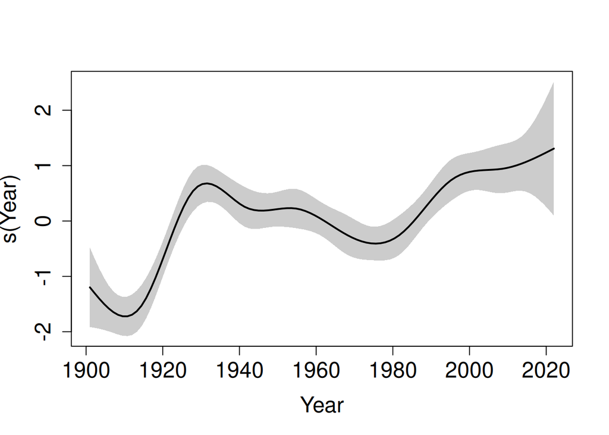

```r
xlim = range(lon) + c(-0.25, 0.25)
ylim = range(lat) + c(-0.25, 0.25)
plot(fit, scheme = 1, which = 2, main = "", lwd = 2, xlab = "Year", ylab = "s(Year)", cex.axis = 1.5, cex = 1.5, cex.lab = 1.5)
```

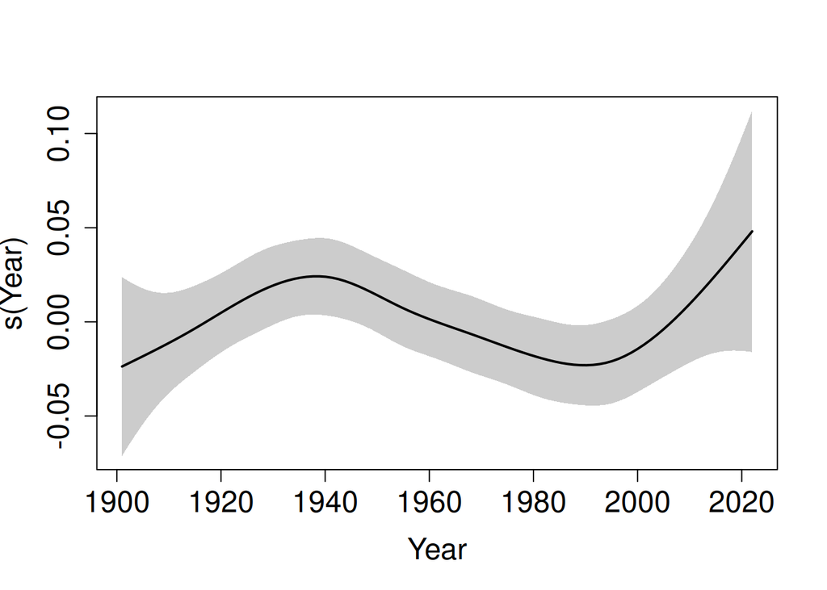

```r
plot(fit, scheme = 1, which = 4, main = "", lwd = 2, xlab = "Year", ylab = "s(Year)", cex.axis = 1.5, cex = 1.5, cex.lab = 1.5)
```

We further generate maps of parameters mu and sigma and of predicted 0.9-quantiles, where we fix the year to 2023.

```
## Scale on map varies by more than 10%, scale bar may be inaccurate
```

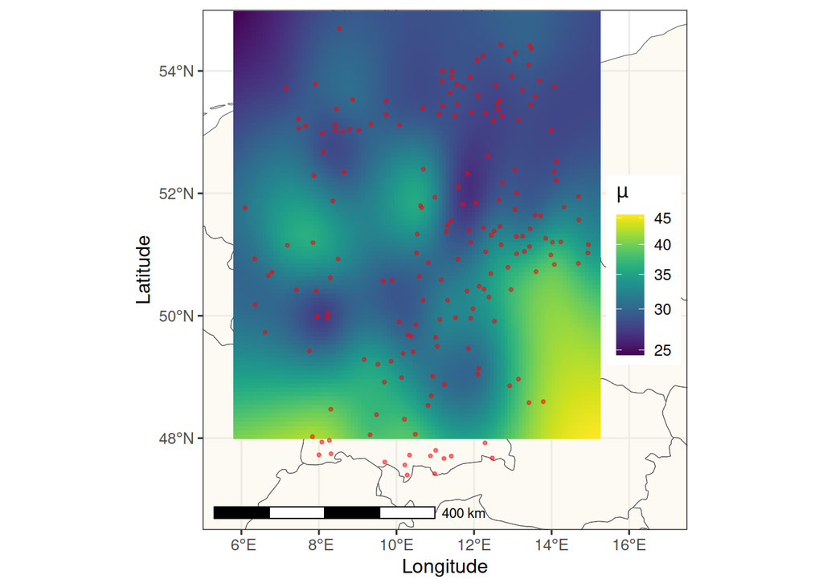

```r
xgrid = seq(from = xlim[1], to = xlim[2], length.out = 100)
ygrid = seq(from = ylim[1]+0.25, to = ylim[2], length.out = 100)
xygrid = expand.grid(xgrid, ygrid)
df_pred = data.frame(lon = xygrid[,1], lat = xygrid[,2], year = 2023)
pred = predict(fit, df_pred, type = "response")
df_pred$Mu = pred$location
df_pred$Sigma = pred$scale
pred = predict(fit, df_pred, type = "quantile", prob = .9)
df_pred$Q90 = pred$`q:0.9`
# Generate pl0 that we will re-use later:
pl0 = ggplot(data = world) + theme_bw(base_size = 12)
pl0 = pl0 + geom_sf(fill= "antiquewhite", alpha = .3)
pl0 = pl0 + annotation_scale(location = 'bl', width_hint = 0.5)
#pl0 = pl0 + annotation_north_arrow(location = 'bl', which_north = 'true', pad_x = unit(0.5, 'in'), pad_y = unit(0.35, 'in'), style = north_arrow_fancy_orienteering)
pl0 = pl0 + coord_sf(xlim = c(5, 17.5), ylim = c(46.5,55), expand = FALSE)
pl0 = pl0 + xlab('Longitude') + ylab('Latitude')
pl0 = pl0 + theme(legend.position = c(0.91, 0.5))
# Generate the specific plot for mu:
pl = pl0
pl = pl + geom_point(aes(x = lon, y = lat, colour = Mu), data = df_pred, shape = 15, size = .98, alpha = 1)
pl = pl + geom_point(aes(x = lon, y = lat), data = df_gg, color = "red", size = .75, alpha = .5)
pl = pl + scale_color_gradientn(colours = viridis(16), trans = "log", labels = function(x) round(x,1))
pl = pl + labs(colour = expression(mu))
print(pl)
```

```
## Scale on map varies by more than 10%, scale bar may be inaccurate
```

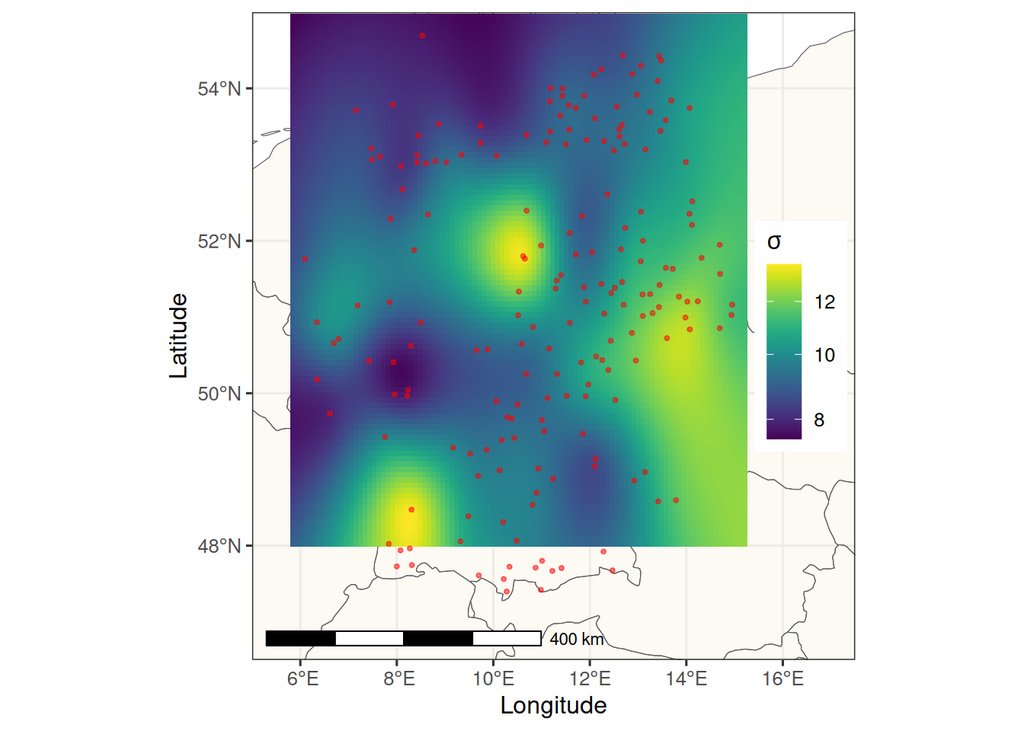

```r
# same plot but for sigma:
pl = pl0
pl = pl + geom_point(aes(x = lon, y = lat, colour = Sigma), data = df_pred, shape = 15, size = .98, alpha = 1)
pl = pl + geom_point(aes(x = lon, y = lat), data = df_gg, color = "red", size = .75, alpha = .5)
pl = pl + scale_color_gradientn(colours = viridis(16), trans = "log", labels = function(x) round(x,1))
pl = pl + labs(colour = expression(sigma))
print(pl)
```

```
## Scale on map varies by more than 10%, scale bar may be inaccurate
```

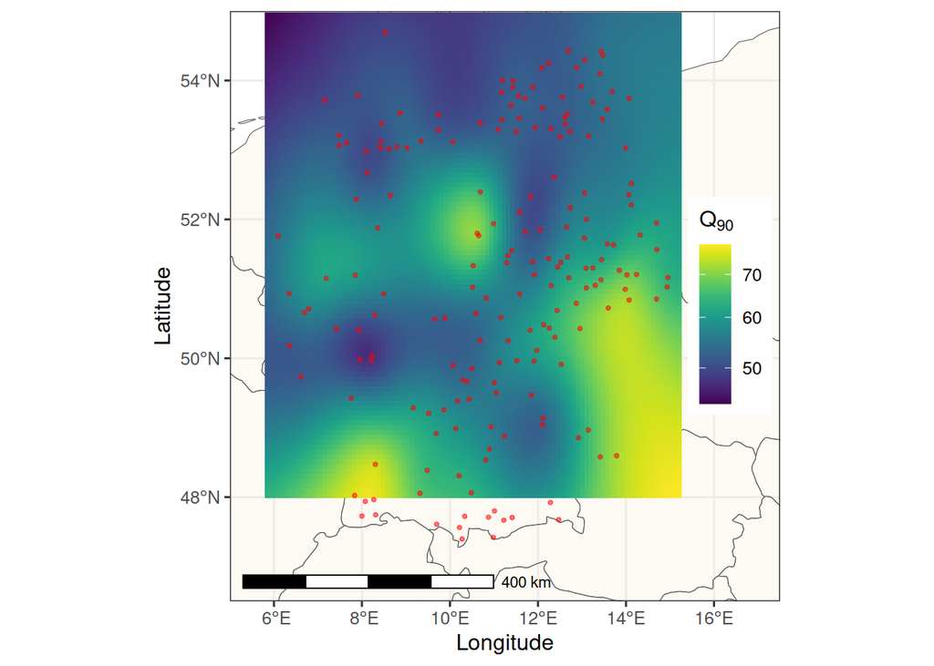

```r
# same plot but for 0.9-quantile:
pl = pl0
pl = pl + geom_point(aes(x = lon, y = lat, colour = Q90), data = df_pred, shape = 15, size = .98, alpha = 1)
pl = pl + geom_point(aes(x = lon, y = lat), data = df_gg, color = "red", size = .75, alpha = .5)
pl = pl + scale_color_gradientn(colours = viridis(16), trans = "log", labels = function(x) round(x,1))
pl = pl + labs(colour = expression(Q[90]))
print(pl)
```

We now perform a similar analyses but using the GP distribution for threshold exceedances. We first extract the thresholds from the considered gauges using the above-defined function myfun, and then we extract positive excesses above the locationwise threshold u. The final line reports the number of observations of excesses that we will use in the GAM with GP response distribution.

```r
u = as.vector(sapply(alldata, myfun))
mean(is.na(u))
```

```
## [1] 0.1136364
```

```r
df = data.frame(y = as.numeric(alldata))
df$year = rep(years, ncol(alldata))
df$u = rep(u, each = nrow(alldata))
df$lat = rep(lat, each = nrow(alldata))
df$lon = rep(lon, each = nrow(alldata))
df$excess = df$y - df$u
df$excess[df$excess <= 0] = NA
sum(!is.na(df$excess))
```

```
## [1] 128096
```

We can now fit the GPD model. Note that it does not have a location parameter, only a scale parameter tilde.sigma (into which we include covariates) and the same shape parameter as the GEV distribution.

```r
form_gpd = list(excess ~ s(lon, lat, k = 50) + s(year, bs = "cr"), ~ 1)
fit_gpd = evgam(form_gpd, df, family = "gpd")
summary(fit_gpd)
```

```
##
## ** Parametric terms **
##
## logscale
##             Estimate Std. Error t value Pr(>|t|)
## (Intercept)     1.88          0  439.29   <2e-16
##
## shape
##             Estimate Std. Error t value Pr(>|t|)
## (Intercept)     0.16          0   47.58   <2e-16
##
## ** Smooth terms **
##
## logscale
##              edf max.df  Chi.sq Pr(>|t|)
## s(lon,lat) 42.38     49 1216.05   <2e-16
## s(year)     5.61      9   34.78 4.67e-06
```

We now generate the same plots as for the GEV. For the quantile map, we choose a level that corresponds to a 10-year return level for 2023 (in stationary conditions). The factor 50=1/(1-0.98) in prob is due to the fact that we have fitted the GP distribution for excesses above the 0.98-quantile.

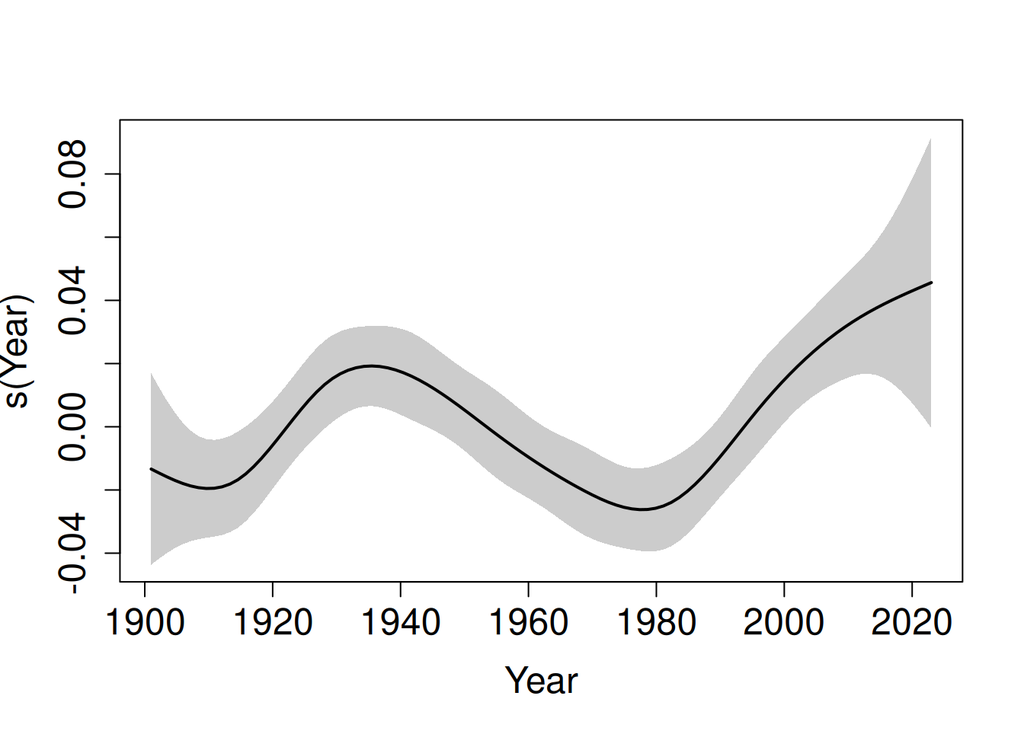

```r
plot(fit_gpd, scheme = 1, which = 2, main = "", lwd = 2, xlab = "Year", ylab = "s(Year)", cex.axis = 1.5, cex = 1.5, cex.lab = 1.5)
```

```r
df_pred_gpd = data.frame(lon = xygrid[,1], lat = xygrid[,2], year = 2023)
pred = predict(fit_gpd, df_pred, type = "response")
df_pred_gpd$Sigma_tilde = pred$scale
prob = 1-50/(10*365.25); prob
```

```
## [1] 0.9863107
```

```
## Scale on map varies by more than 10%, scale bar may be inaccurate
```

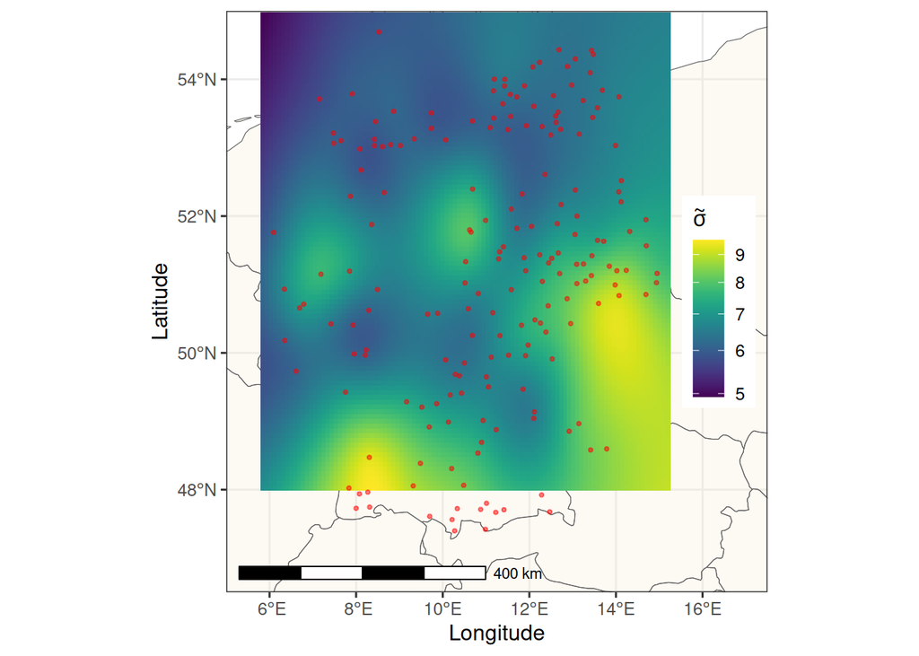

```r
pred = predict(fit_gpd, df_pred_gpd, type = "quantile", prob = prob)
df_pred_gpd$Q = pred$`q:0.986`
pl = pl0
pl = pl + geom_point(aes(x = lon, y = lat, colour = Sigma_tilde), data = df_pred_gpd, shape = 15, size = .98, alpha = 1)
pl = pl + geom_point(aes(x = lon, y = lat), data = df_gg, color = "red", size = .75, alpha = .5)
pl = pl + scale_color_gradientn(colours = viridis(16), trans = "log", labels = function(x) round(x,1))
pl = pl + labs(colour = expression(tilde(sigma)))
print(pl)
```

```
## Scale on map varies by more than 10%, scale bar may be inaccurate
```

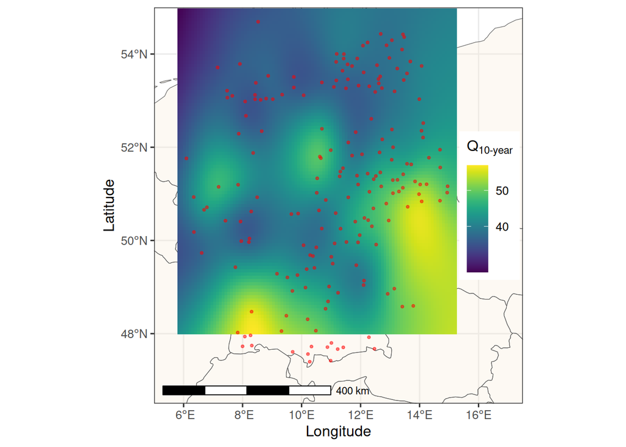

```r
pl = pl0
pl = pl + geom_point(aes(x = lon, y = lat, colour = Q), data = df_pred_gpd, shape = 15, size = .98, alpha = 1)
pl = pl + geom_point(aes(x = lon, y = lat), data = df_gg, color = "red", size = .75, alpha = .5)
pl = pl + scale_color_gradientn(colours = viridis(16), trans = "log", labels = function(x) round(x,1))
pl = pl + labs(colour = expression(Q[10-year]))
print(pl)
```